# HW 4

Alex Norman

October 25, 2016

## Homework 4 Assignment

This homework assignment is about bootstrapping to illustrate the central limit theorem. We will look at both the normal distribution with two different sample sizes and exponential with two different sample sizes.

## Normal Distributions

First we will look at a normal distirbution with the sample size of 10 to illustrate clt.

```r
#We are using a sample size of 10
n <- 10
nsim <- 1000
clt.norm.small <- numeric(nsim)
#looping through this function for i equals 1 through nism times which in this case is 1000
for (i in 1:nsim) {
#Assigning x to be a random value with normal distribution from the sample size of 10 with replacement
  x <- rnorm(n)
#finding the mean for each i where i equals 1 through 1000
  clt.norm.small[i] <- mean(x)
}
#This is getting the five figure summary
summary(clt.norm.small)
```

```
##      Min.   1st Qu.    Median      Mean   3rd Qu.      Max.
## -0.927800 -0.218100 -0.001170  0.003057  0.215100  1.081000
```

```r
#This lets us know how many values
length(clt.norm.small)
```

```
## [1] 1000
```

```r
#This gives us the mean
mean(clt.norm.small)
```

```
## [1] 0.003056919
```

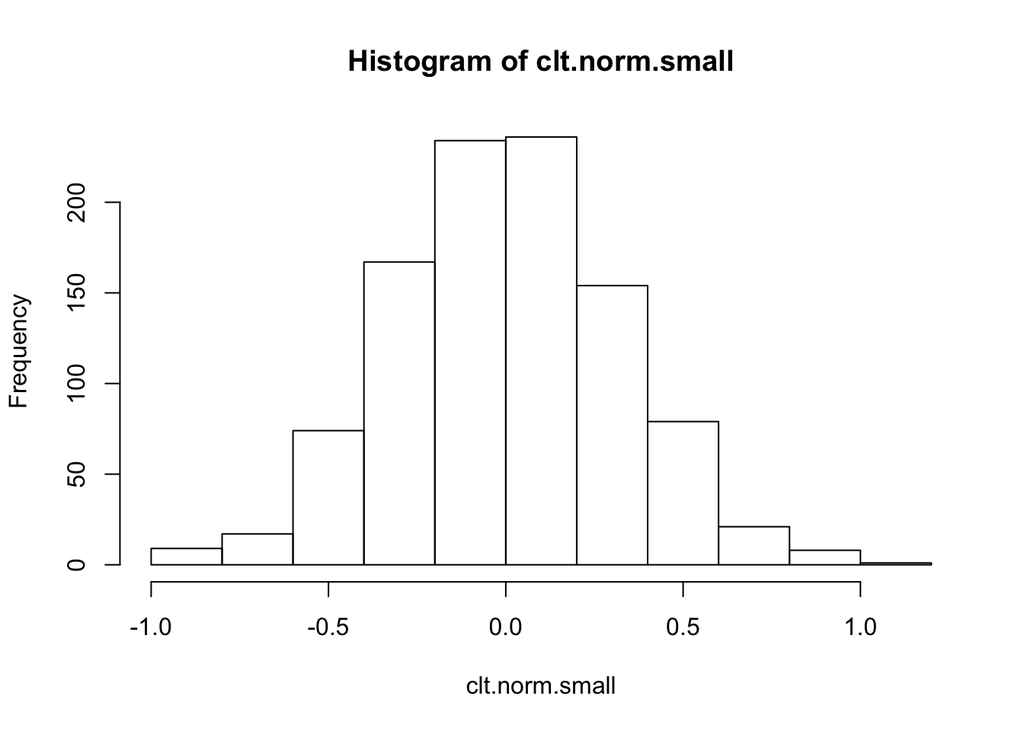

```r
#This will plot a histogram so we can see the central limit theorem
hist(clt.norm.small)
```

From the five figure summary we are able to see the range, 1st and 3rd Quartile, median and mean that spans roughly from -1 to 1. From the length we get 1000 which is what we expected since that is the amount of times it will run through the loop The mean should be close to 0 since that is the mean for a normal distribution. From the histogram we can see that the graph has a normal distribution and is centered around 0.

Next we will look at a normal distribution with the sample size of 1000 to illustrate clt.

```r
#we have increased our sample size to 1000
m <- 1000
nsim <- 1000
clt.norm.big <- numeric(nsim)
#looping through this function for i equals 1 through nism times which in this case is 1000
for (i in 1:nsim) {
  #Assigning x to be a random value with normal distribution from the sample size of 1000 with replacement
  x <- rnorm(m)
  #finding the mean for each i where i equals 1 through 1000
  clt.norm.big[i] <- mean(x)
}

#This is getting the five figure summary
summary(clt.norm.big)
```

```
##       Min.    1st Qu.     Median       Mean    3rd Qu.       Max.
## -0.1050000 -0.0204400 -0.0006618 -0.0003634  0.0202200  0.0967000
```

```r
#This lets us know how many values we would expect this to be 1000 since that is the amount of times we want to run through the loop
length(clt.norm.big)
```

```
## [1] 1000
```

```r
#This gives us the mean we want this to be close to 0
mean(clt.norm.big)
```

```
## [1] -0.0003633855
```

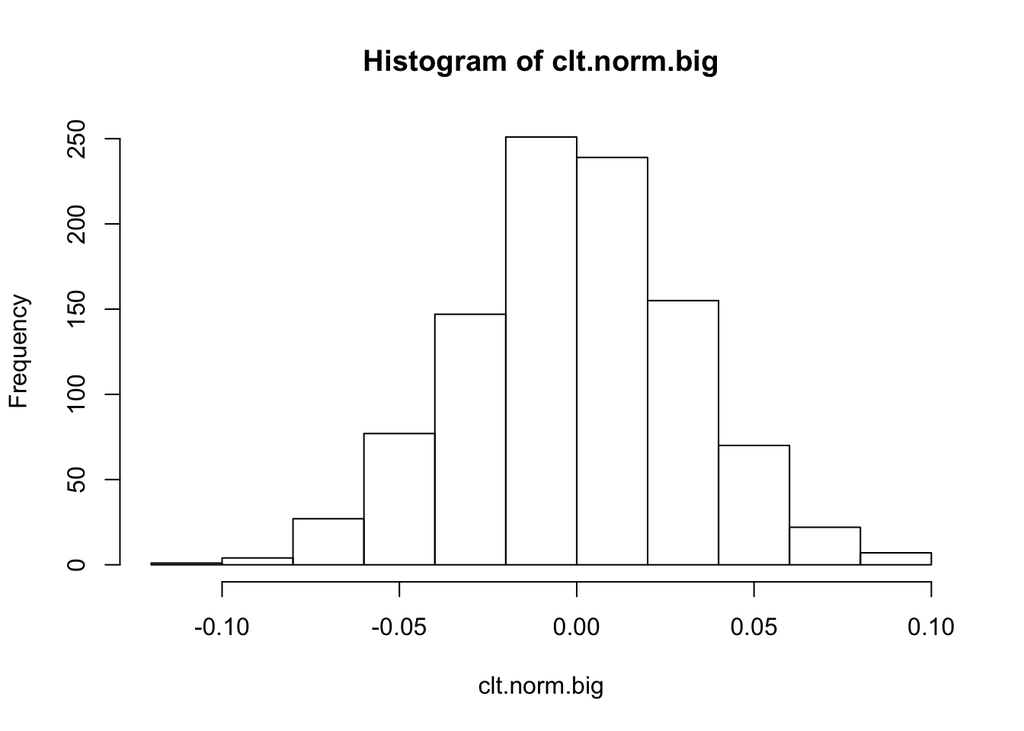

```r
#This will plot a histogram so we can see the central limit theorem
hist(clt.norm.big)
```

From the five figure summary we are able to see the range, 1st and 3rd Quartile, median and mean which has a smaller span than the pervious example with a smaller sample size. From the length we get 1000 which is what we expected since that is the amount of times it will run through the loop. The mean should be close to 0 since that is the mean for a normal distribution and the mean of the larger sample size should be closer to 0 than the one with a smaller sample size. From the histogram we can see that the graph has a normal distribution and is centered around 0 and it is much narrower than the graph with a sample size of 0.

## Exponential Distributions

Now we will look at an exponential distribution with the sample size of 10 to illustrate clt.

```r
#We are using a sample size of 10
l <- 10
nsim <- 1000
clt.exp.small <- numeric(nsim)
#looping through this function for i equals 1 through nism times which in this case is 1000
for (i in 1:nsim) {
#Assigning x to be a random value with exponential distribution from the sample size of 10 with replacement
  x <- rexp(l)
#Finding the mean for each i where i equals 1 through 1000
  clt.exp.small[i] <- mean(x)
}
#This is getting the five figure summary
summary(clt.exp.small)
```

```
##    Min. 1st Qu.  Median    Mean 3rd Qu.    Max.
##  0.1661  0.7602  0.9588  0.9890  1.1880  2.4640
```

```r
#This lets us know how many values we would expect this to be 1000 since that is the amount of times we want to run through the loop
length(clt.exp.small)
```

```
## [1] 1000
```

```r
#This gives us the mean we want this close to 1
mean(clt.exp.small)
```

```
## [1] 0.9889727
```

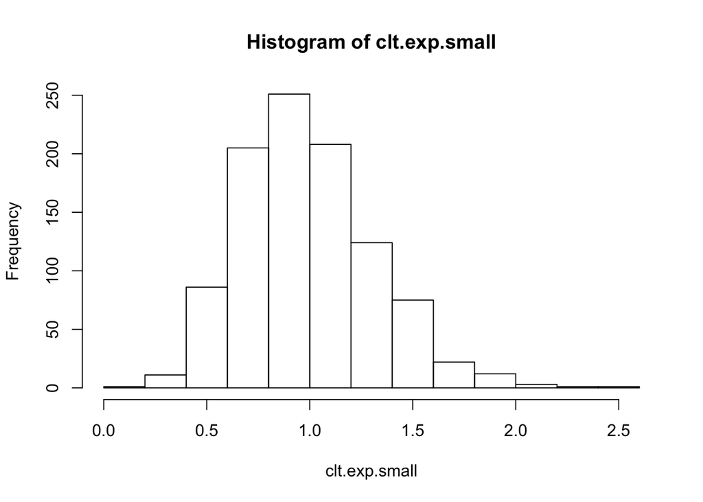

```r
#This will plot a histogram so we can see the central limit theorem
hist(clt.exp.small)
```

From the five figure summary we are able to see the range, 1st and 3rd Quartile, median and mean. From the length we get 1000 which is what we expected since that is the amount of times it will run through the loop. The mean should be close to 1 since that is the mean for a exponential distribution. From the histogram we can see that the graph is starting to look like a normal distribution centered around one but is still slightly skewed to the right.

Finally we will look at an exponential distribution with the sample size of 1000 to illustrate clt.

```r
#We are using a sample size of 1000
j <- 1000
nsim <- 1000
clt.exp.big <- numeric(nsim)
#looping through this function for i equals 1 through nism times which in this case is 1000
for (i in 1:nsim) {
  #Assigning x to be a random value with exponential distribution from the sample size of 1000 with replacement
  x <- rexp(j)
  #Finding the mean for each i where i equals 1 through 1000
  clt.exp.big[i] <- mean(x)
}
#This is getting the five figure summary
summary(clt.exp.big)
```

```
##    Min. 1st Qu.  Median    Mean 3rd Qu.    Max.
##  0.8993  0.9791  0.9995  1.0000  1.0200  1.1120
```

```r
#This lets us know how many values we would expect this to be 1000 since that is the amount of times we want to run through the loop
length(clt.exp.big)
```

```
## [1] 1000
```

```r
#This gives us the mean we want this close to 1
mean(clt.exp.big)
```

```
## [1] 0.9999845
```

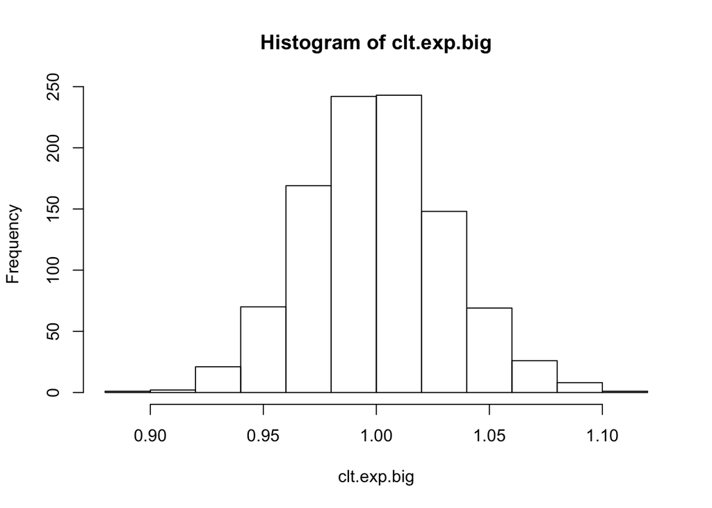

```r
#This will plot a histogram so we can see the central limit theorem
hist(clt.exp.big)
```

From the five figure summary we are able to see the range, 1st and 3rd Quartile, median and mean this has a smaller range than the smaller sample size did. From the length we get 1000 which is what we expected since that is the amount of times it will run through the loop. The mean should be close to 1 since that is the mean for a exponential distribution and even closer to 1 than the smaller sample size. From the histogram we can see that the graph looks even more like a normal distribution centered around 1 than the smaller sample size and is more condensed.